# 01 -- Explainer comparison: faithfulness vs. plausibility

**Project 2 — `02-text-eraser`**

This notebook summarises the quantitative results from the full evaluation run and provides a qualitative look at individual token attributions.

**Before running** this notebook, the evaluation pipeline must have completed:

```
just data && just prepare && just train && just explain && just eval
```

The notebook will detect missing outputs early and print a clear error rather than crashing mid-cell. All cells below are idempotent once the outputs are present.

### What we are measuring

We fine-tune `roberta-base` on the ERASER Movies sentiment dataset (the spec named `microsoft/deberta-v3-base`, but DeBERTa-v3 NaNs under this env's stack — see ADR 002) and run four explainers — LIME, Integrated Gradients, Gradient×Input, and (optionally) SHAP PartitionExplainer — plus a **random baseline** that assigns uniform random attribution scores. For each explainer we compute:

| Dimension | Metrics |
| --- | --- |
| **Faithfulness** | Comprehensiveness, Sufficiency (at budget `k_d`), AOPC |
| **Plausibility** | Token P/R/F1 at `k_d`, AUPRC |

Bootstrap 95% CIs (paired, 2 000 resamples) and pairwise Bonferroni-corrected significance tests are reported alongside every number.

See `REPORT.md` for the full methodology and limitations.

```python
# ---------------------------------------------------------------------------
# Imports
# ---------------------------------------------------------------------------
"""Explainer comparison notebook: faithfulness vs. plausibility."""
from __future__ import annotations

import contextlib
import json
import os
import pathlib
import sys
import warnings

import matplotlib.pyplot as plt
import numpy as np
import pandas as pd

# Matplotlib style — matches the portfolio palette from P1
with contextlib.suppress(ImportError):
    import awake.viz.style  # noqa: F401  (registers the style on import)
```

```python
# ---------------------------------------------------------------------------
# Paths
# ---------------------------------------------------------------------------
# Locate the project root robustly. ``__file__`` is undefined when nbconvert executes the
# notebook and the kernel cwd may be $HOME, so prefer an explicit env var (set by
# ``just notebook``), then fall back to several candidate paths, picking the first that
# actually contains the project (``configs/model.yaml`` or a produced ``metrics.json``).
_candidates = []
if os.environ.get("P2_PROJECT_ROOT"):
    _candidates.append(pathlib.Path(os.environ["P2_PROJECT_ROOT"]))
with contextlib.suppress(NameError):
    _candidates.append(pathlib.Path(__file__).resolve().parent.parent)
_cwd = pathlib.Path.cwd()
_candidates += [_cwd, _cwd.parent, _cwd / "projects" / "02-text-eraser"]
PROJECT_ROOT = next(
    (
        d
        for d in _candidates
        if (d / "configs" / "model.yaml").exists() or (d / "metrics.json").exists()
    ),
    _cwd.parent,
)
METRICS_PATH = PROJECT_ROOT / "metrics.json"
HERO_PATH = PROJECT_ROOT / "assets" / "faithfulness_plausibility.png"
ATTRIBUTION_CACHE_DIR = PROJECT_ROOT / "outputs" / "attributions"
PREPARED_TEST = PROJECT_ROOT / "outputs" / "prepared" / "test.parquet"
```

```python
# ---------------------------------------------------------------------------
# Guard: check that the pipeline has run
# ---------------------------------------------------------------------------
_missing = []
if not METRICS_PATH.exists():
    _missing.append(str(METRICS_PATH))
if not HERO_PATH.exists():
    _missing.append(str(HERO_PATH))

if _missing:
    print(
        "ERROR: The following outputs were not found:\n"
        + "\n".join(f"  {p}" for p in _missing)
        + "\n\nPlease run the evaluation pipeline first:\n"
        "  just eval\n"
        "from the project root (or `just pipeline && just eval` for a full run).",
        file=sys.stderr,
    )
    raise FileNotFoundError(
        "Pipeline outputs missing — run `just eval` first.  "
        "See the cell above for details."
    )
```

```python
# ---------------------------------------------------------------------------
# Load metrics.json
# ---------------------------------------------------------------------------
with METRICS_PATH.open() as fh:
    metrics_raw: dict = json.load(fh)

# Top-level keys (see scripts/30_eval.py):
#   "metrics":                    {explainer_name: {metric: {ci_low, mean, ci_high}, ...}}
#   "pairwise_comprehensiveness": {"{a}_vs_{b}": {mean_diff, p_value, significant, ...}}
#   "diagnostics":                {accuracy, macro_f1, ece, class_balance, n}

explainers_data: dict = metrics_raw.get("metrics", {})
classifier_data: dict = metrics_raw.get("diagnostics", {})
pairwise_data: dict = metrics_raw.get("pairwise_comprehensiveness", {})

if not explainers_data:
    warnings.warn(
        "metrics.json loaded but 'metrics' key is empty — "
        "did `just eval` complete successfully?",
        stacklevel=1,
    )
```

```python
# ---------------------------------------------------------------------------
# Classifier diagnostics
# ---------------------------------------------------------------------------
print("=== Classifier diagnostics ===")
for k, v in classifier_data.items():
    if isinstance(v, float):
        print(f"  {k}: {v:.4f}")
    else:
        print(f"  {k}: {v}")
```

```
=== Classifier diagnostics ===
  accuracy: 0.9246
  macro_f1: 0.9246
  ece: 0.0613
  class_balance: 0.4975
  n: 199
```

## 1. Per-explainer metric table

The table below shows faithfulness and plausibility metrics for every explainer, including the **random baseline** floor. Bootstrap 95% confidence intervals are shown as `[lo, hi]`. Numbers are populated from `metrics.json`; the run is described in `REPORT.md §6`.

```python
# ---------------------------------------------------------------------------
# Build summary table
# ---------------------------------------------------------------------------
_METRIC_LABELS = {
    "comprehensiveness": "Comp.",
    "sufficiency": "Suff.",
    "aopc": "AOPC",
    "token_f1": "Token F1",
    "auprc": "AUPRC",
}

rows = []
for explainer_name, mdict in explainers_data.items():
    row: dict[str, object] = {"Explainer": explainer_name}
    for metric_key, col_label in _METRIC_LABELS.items():
        entry = mdict.get(metric_key, {})
        mean = entry.get("mean", float("nan"))
        ci_lo = entry.get("ci_low", float("nan"))
        ci_hi = entry.get("ci_high", float("nan"))
        row[col_label] = f"{mean:.3f} [{ci_lo:.3f}, {ci_hi:.3f}]"
    rows.append(row)

df_metrics = pd.DataFrame(rows).set_index("Explainer")

print("\n=== Per-explainer faithfulness + plausibility ===")
print(df_metrics.to_string())
df_metrics  # noqa: B018  (intentional notebook display expression)
```

```
=== Per-explainer faithfulness + plausibility ===
                                     Comp.                  Suff.                  AOPC              Token F1                 AUPRC
Explainer
random                0.056 [0.030, 0.084]   0.322 [0.281, 0.366]  0.047 [0.032, 0.062]  0.181 [0.169, 0.193]  0.302 [0.279, 0.327]
grad_x_input          0.027 [0.004, 0.055]   0.354 [0.307, 0.401]  0.033 [0.018, 0.049]  0.225 [0.211, 0.239]  0.333 [0.309, 0.358]
integrated_gradients  0.520 [0.456, 0.583]  0.016 [-0.000, 0.036]  0.340 [0.306, 0.376]  0.211 [0.196, 0.226]  0.327 [0.303, 0.352]
lime                  0.015 [0.000, 0.032]   0.346 [0.303, 0.392]  0.037 [0.026, 0.050]  0.197 [0.187, 0.207]  0.321 [0.298, 0.345]
```

| Explainer | Comp. | Suff. | AOPC | Token F1 | AUPRC |
| --- | --- | --- | --- | --- | --- |
| random | 0.056 [0.030, 0.084] | 0.322 [0.281, 0.366] | 0.047 [0.032, 0.062] | 0.181 [0.169, 0.193] | 0.302 [0.279, 0.327] |
| grad_x_input | 0.027 [0.004, 0.055] | 0.354 [0.307, 0.401] | 0.033 [0.018, 0.049] | 0.225 [0.211, 0.239] | 0.333 [0.309, 0.358] |
| integrated_gradients | 0.520 [0.456, 0.583] | 0.016 [-0.000, 0.036] | 0.340 [0.306, 0.376] | 0.211 [0.196, 0.226] | 0.327 [0.303, 0.352] |
| lime | 0.015 [0.000, 0.032] | 0.346 [0.303, 0.392] | 0.037 [0.026, 0.050] | 0.197 [0.187, 0.207] | 0.321 [0.298, 0.345] |

## 2. Hero scatter — faithfulness vs. plausibility

The random baseline occupies the bottom-left corner, setting the floor: any explainer that does not meaningfully exceed it on *both* axes is providing neither faithful nor plausible attributions.

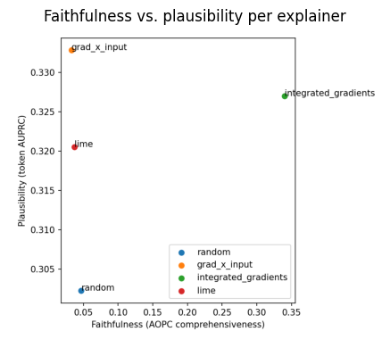

```python
# ---------------------------------------------------------------------------
# Display hero figure (pre-rendered by scripts/30_eval.py)
# ---------------------------------------------------------------------------
fig, ax = plt.subplots(figsize=(6, 4))
try:
    img = plt.imread(str(HERO_PATH))
    ax.imshow(img)
    ax.axis("off")
    ax.set_title("Faithfulness vs. plausibility per explainer")
except Exception as exc:
    ax.text(
        0.5,
        0.5,
        f"Could not load hero figure:\n{exc}\n\nRun `just eval` to generate it.",
        ha="center",
        va="center",
        transform=ax.transAxes,
        fontsize=10,
        color="firebrick",
    )
plt.tight_layout()
plt.show()
```

## 3. Token heatmaps — qualitative inspection

The examples are picked as the first two from the evaluation subsample that satisfy `truncation_coverage >= 0.8` so that the gold rationale mask is largely intact in the visible window.

```python
# ---------------------------------------------------------------------------
# Load a small slice of the attribution cache for the heatmap
# ---------------------------------------------------------------------------

HEATMAP_N = 2  # number of examples to visualise

_EXPLAINER_ORDER = [
    "lime",
    "integrated_gradients",
    "grad_x_input",
    "shap_partition",
    "random",
]

_cache_available = ATTRIBUTION_CACHE_DIR.exists() and any(
    ATTRIBUTION_CACHE_DIR.glob("*.parquet")
)
_prepared_available = PREPARED_TEST.exists()

if not _cache_available or not _prepared_available:
    print(
        "Attribution cache or prepared test parquet not found.\n"
        "Run `just explain` (and `just prepare` if needed) to generate them.\n"
        "Skipping token heatmap cells.",
        file=sys.stderr,
    )
    _skip_heatmaps = True
else:
    _skip_heatmaps = False
```

```python
# ---------------------------------------------------------------------------
# Helper: render one example as an HTML token heatmap (displayed via IPython)
# ---------------------------------------------------------------------------
from IPython.display import HTML, display  # noqa: E402


def _score_to_hex(score: float, cmap_name: str = "RdYlGn") -> str:
    """Map a normalised score in [0, 1] to an RGB hex colour."""
    cmap = plt.get_cmap(cmap_name)
    r, g, b, _ = cmap(float(score))
    return f"#{int(r*255):02x}{int(g*255):02x}{int(b*255):02x}"


def render_token_heatmap(
    tokens: list[str],
    scores_per_explainer: dict[str, np.ndarray],
) -> HTML:
    """Return an HTML table with one column per explainer and coloured tokens."""
    explainer_names = list(scores_per_explainer.keys())
    header = "".join(f"<th>{n}</th>" for n in explainer_names)
    cells = ""
    for i, tok in enumerate(tokens):
        cells += "<tr>"
        for name in explainer_names:
            scores = scores_per_explainer[name]
            val = float(scores[i]) if i < len(scores) else 0.0
            bg = _score_to_hex(val)
            cells += (
                f'<td style="background:{bg};padding:2px 4px;'
                f'font-family:monospace;font-size:11px;">{tok}</td>'
            )
        cells += "</tr>"
    html = (
        "<table style='border-collapse:collapse'>"
        f"<thead><tr>{header}</tr></thead>"
        f"<tbody>{cells}</tbody>"
        "</table>"
    )
    return HTML(html)


_SPECIAL_TOKENS = {"<s>", "</s>", "<pad>", "<unk>", "<mask>"}


def reconstruct_text(tokens: list[str]) -> str:
    """Detokenise RoBERTa byte-level BPE tokens back to readable text.

    'G-with-dot' marks a leading space and 'C-with-dot' a newline in RoBERTa's
    byte-level vocabulary; special tokens are dropped. The result is the actual model
    input, made legible (no raw review file is read -- this is the tokenised input the
    explainers scored, rendered back to text).
    """
    parts = []
    for tok in tokens:
        if tok in _SPECIAL_TOKENS:
            continue
        lead = " " if tok.startswith("Ġ") else ""
        parts.append(lead + tok.replace("Ġ", "").replace("Ċ", " "))
    return "".join(parts).strip()


def render_readable_highlight(
    tokens: list[str],
    norm_scores: np.ndarray,
    top_frac: float = 0.15,
) -> HTML:
    """Render the reconstructed review with the top-scoring tokens highlighted inline.

    Maps each token's (normalised) attribution onto the readable text, so the rationale
    an explainer selected is visible as highlighted words rather than as an abstract
    subword grid.
    """
    scores = np.asarray(norm_scores, dtype=float)
    thresh = float(np.quantile(scores, 1.0 - top_frac)) if scores.size else 1.1
    spans = []
    for tok, sc in zip(tokens, scores, strict=False):
        if tok in _SPECIAL_TOKENS:
            continue
        lead = " " if tok.startswith("Ġ") else ""
        word = tok.replace("Ġ", "").replace("Ċ", " ")
        if sc >= thresh:
            spans.append(f'{lead}<mark style="background:#ffd54a;padding:0 1px">{word}</mark>')
        else:
            spans.append(lead + word)
    body = "".join(spans).strip()
    return HTML(
        '<div style="font-family:Georgia,serif;font-size:13px;line-height:1.7;'
        f'max-width:760px">{body}</div>'
    )
```

```python
# ---------------------------------------------------------------------------
# Load attribution caches and prepared test data; render heatmaps
# ---------------------------------------------------------------------------
if not _skip_heatmaps:
    try:
        # The subsample drives the cache's example_id (0-based positional id), and each
        # cache carries its own token_str/score grid — render each explainer on its own
        # tokens so a heatmap reflects exactly what that explainer scored.
        subsample = pd.read_parquet(ATTRIBUTION_CACHE_DIR / "subsample.parquet").reset_index(
            drop=True
        )
        _attr_caches: dict[str, pd.DataFrame] = {}
        for parquet_file in sorted(ATTRIBUTION_CACHE_DIR.glob("*.parquet")):
            if parquet_file.stem == "subsample":
                continue
            _attr_caches[parquet_file.stem] = pd.read_parquet(parquet_file)

        # Prefer high-coverage examples for a fairer qualitative look.
        _cov = subsample["truncation_coverage"]
        _ids = subsample.index[_cov >= 0.8].tolist()[:HEATMAP_N]
        if not _ids:
            _ids = subsample.index.tolist()[:HEATMAP_N]

        # Headline explainer for the readable-text highlight (fall back to first present).
        _highlight_expl = next(
            (e for e in ("integrated_gradients", *_EXPLAINER_ORDER) if e in _attr_caches),
            None,
        )

        for _n, example_id in enumerate(_ids):
            row = subsample.loc[example_id]
            _label_txt = "hateful/positive (1)" if int(row["label"]) == 1 else "benign/negative (0)"
            print(f"\n--- Example {_n + 1} (id={example_id}) ---")
            print(f"Label: {row['label']} ({_label_txt})  |  coverage: {row['truncation_coverage']:.2f}")

            # Readable reconstruction with the headline explainer's top tokens highlighted,
            # so the rationale is visible as actual review phrases (not just a subword grid).
            if _highlight_expl is not None:
                _hl_rows = (
                    _attr_caches[_highlight_expl]
                    .query("example_id == @example_id")
                    .sort_values("token_idx")
                )
                if not _hl_rows.empty:
                    _hl_toks = _hl_rows["token_str"].tolist()
                    _hl_raw = _hl_rows["score"].to_numpy(dtype=float)
                    _lo, _hi = _hl_raw.min(), _hl_raw.max()
                    _hl_norm = (
                        (_hl_raw - _lo) / (_hi - _lo)
                        if _hi > _lo
                        else np.full_like(_hl_raw, 0.5)
                    )
                    print(f"  Reconstructed input (top-15% tokens by {_highlight_expl} highlighted):")
                    display(render_readable_highlight(_hl_toks, _hl_norm))

            print("  Per-explainer subword attribution (first 60 tokens):")
            for expl_name in _EXPLAINER_ORDER:
                df_cache = _attr_caches.get(expl_name)
                if df_cache is None:
                    continue
                ex_rows = df_cache[df_cache["example_id"] == example_id].sort_values("token_idx")
                if ex_rows.empty:
                    continue
                toks = ex_rows["token_str"].tolist()
                raw_scores = ex_rows["score"].to_numpy(dtype=float)
                s_min, s_max = raw_scores.min(), raw_scores.max()
                norm = (
                    (raw_scores - s_min) / (s_max - s_min)
                    if s_max > s_min
                    else np.full_like(raw_scores, 0.5)
                )
                print(f"  {expl_name}:")
                display(render_token_heatmap(toks[:60], {expl_name: norm[:60]}))

    except Exception as exc:
        print(f"Heatmap rendering failed: {exc}\nRun `just explain` to regenerate "
              "the attribution cache.", file=sys.stderr)
```

```
--- Example 1 (id=74) ---
Label: 0 (benign/negative (0))  |  coverage: 1.00
  Reconstructed input (top-15% tokens by integrated_gradients highlighted):
```

it 's a good thing most animated sci - fi movies come from japan , because " titan a. e. " is proof that hollywood does n't have a clue how to do it . i do n't know what this film is supposed to be about . from what i can tell it 's about a young man named kale who 's one of the last survivors of earth in the early 31st century who unknowingly possesses the key to saving and re - generating what is left of the human race . that 's a fine premise for an action - packed sci - fi animated movie , but there 's no payoff . the story takes the main characters all over the galaxy in their search for a legendary ship that the evil " dredge " aliens want to destroy for no apparent reason . so in the process we get a lot of spaceship fights , fistfights , blaster fights and more double - crosses than you can shake a stick at . there 's so much pointless sci - fi banter it 's too much to take . the galaxy here is a total rip - off of the " star wars " universe the creators do n't bother filling in the basic details which makes the story confusing , the characters unmotivated and superficial and the plot just plain boring . despite the fantastic animation and special effects , it 's just not an interesting movie .

```
  Per-explainer subword attribution (first 60 tokens):
  lime:
```

| lime |
| --- |
| it |
| 's |
| a |
| good |
| thing |
| most |
| animated |
| sci |
| - |
| fi |
| movies |
| come |
| from |
| japan |
| , |
| because |
| " |
| titan |
| a. |
| e. |
| " |
| is |
| proof |
| that |
| hollywood |
| does |
| n't |
| have |
| a |
| clue |
| how |
| to |
| do |
| it |
| . |
| i |
| do |
| n't |
| know |
| what |
| this |
| film |
| is |
| supposed |
| to |
| be |
| about |
| . |
| from |
| what |
| i |
| can |
| tell |
| it |
| 's |
| about |
| a |
| young |
| man |
| named |

```
  integrated_gradients:
```

| integrated_gradients |
| --- |
| it |
| Ġ' |
| s |
| Ġa |
| Ġgood |
| Ġthing |
| Ġmost |
| Ġanimated |
| Ġsci |
| Ġ- |
| Ġfi |
| Ġmovies |
| Ġcome |
| Ġfrom |
| Ġj |
| apan |
| Ġ, |
| Ġbecause |
| Ġ" |
| Ġtitan |
| Ġa |
| . |
| Ġe |
| . |
| Ġ" |
| Ġis |
| Ġproof |
| Ġthat |
| Ġh |
| ollywood |
| Ġdoes |
| Ġn |
| 't |
| Ġhave |
| Ġa |
| Ġclue |
| Ġhow |
| Ġto |
| Ġdo |
| Ġit |
| Ġ. |
| Ċ |
| i |
| Ġdo |
| Ġn |
| 't |
| Ġknow |
| Ġwhat |
| Ġthis |
| Ġfilm |
| Ġis |
| Ġsupposed |
| Ġto |
| Ġbe |
| Ġabout |
| Ġ. |
| Ċ |
| from |
| Ġwhat |

```
  grad_x_input:
```

| grad_x_input |
| --- |
| it |
| Ġ' |
| s |
| Ġa |
| Ġgood |
| Ġthing |
| Ġmost |
| Ġanimated |
| Ġsci |
| Ġ- |
| Ġfi |
| Ġmovies |
| Ġcome |
| Ġfrom |
| Ġj |
| apan |
| Ġ, |
| Ġbecause |
| Ġ" |
| Ġtitan |
| Ġa |
| . |
| Ġe |
| . |
| Ġ" |
| Ġis |
| Ġproof |
| Ġthat |
| Ġh |
| ollywood |
| Ġdoes |
| Ġn |
| 't |
| Ġhave |
| Ġa |
| Ġclue |
| Ġhow |
| Ġto |
| Ġdo |
| Ġit |
| Ġ. |
| Ċ |
| i |
| Ġdo |
| Ġn |
| 't |
| Ġknow |
| Ġwhat |
| Ġthis |
| Ġfilm |
| Ġis |
| Ġsupposed |
| Ġto |
| Ġbe |
| Ġabout |
| Ġ. |
| Ċ |
| from |
| Ġwhat |

```
  random:
```

| random |
| --- |
| it |
| Ġ' |
| s |
| Ġa |
| Ġgood |
| Ġthing |
| Ġmost |
| Ġanimated |
| Ġsci |
| Ġ- |
| Ġfi |
| Ġmovies |
| Ġcome |
| Ġfrom |
| Ġj |
| apan |
| Ġ, |
| Ġbecause |
| Ġ" |
| Ġtitan |
| Ġa |
| . |
| Ġe |
| . |
| Ġ" |
| Ġis |
| Ġproof |
| Ġthat |
| Ġh |
| ollywood |
| Ġdoes |
| Ġn |
| 't |
| Ġhave |
| Ġa |
| Ġclue |
| Ġhow |
| Ġto |
| Ġdo |
| Ġit |
| Ġ. |
| Ċ |
| i |
| Ġdo |
| Ġn |
| 't |
| Ġknow |
| Ġwhat |
| Ġthis |
| Ġfilm |
| Ġis |
| Ġsupposed |
| Ġto |
| Ġbe |
| Ġabout |
| Ġ. |
| Ċ |
| from |
| Ġwhat |

```
--- Example 2 (id=75) ---
Label: 0 (benign/negative (0))  |  coverage: 1.00
  Reconstructed input (top-15% tokens by integrated_gradients highlighted):
```

capsule : john the baptist is sent from heaven to see is the world is worth saving . he must find some sign of hope in the people of newfoundland . this is little more than a tv skit in movie form . it is watchable and apparently will be released to theaters in canada , but it is unlikely to be seen on the international market . it is diverting but hardly a serious piece of cinema . , 0 ( -4 to +4 ) minor spoilers in this review . - written and directed by john w. doyle . - john the baptist sent to st . john , newfoundland . gets an invitation to live with a family . that extraordinary hospitality for some reason does not count as a reason for hope . - script has a lot of holes . - friend who adopts john is surprisingly militant and is planning actions to destabilize wall street . - john does look middle eastern , but somehow one expects john the baptist to be more dramatic . - there is a conspiracy in the vatican riding on the result of the visit , though that result seems small compared to the end of the world . - big yucks like seeing a nun give the pope a pedicure and evil pope 's aid praying to a mendes goat . - in large part a satire of life in newfoundland taking licks at things like the poor produce . the one good tomato in grocery ( by virtue of a miracle ) " must have fallen off the truck to toronto . " - based on a 20-minute short film .

```
  Per-explainer subword attribution (first 60 tokens):
  lime:
```

| lime |
| --- |
| capsule |
| : |
| john |
| the |
| baptist |
| is |
| sent |
| from |
| heaven |
| to |
| see |
| is |
| the |
| world |
| is |
| worth |
| saving |
| . |
| he |
| must |
| find |
| some |
| sign |
| of |
| hope |
| in |
| the |
| people |
| of |
| newfoundland |
| . |
| this |
| is |
| little |
| more |
| than |
| a |
| tv |
| skit |
| in |
| movie |
| form |
| . |
| it |
| is |
| watchable |
| and |
| apparently |
| will |
| be |
| released |
| to |
| theaters |
| in |
| canada |
| , |
| but |
| it |
| is |
| unlikely |

```
  integrated_gradients:
```

| integrated_gradients |
| --- |
| caps |
| ule |
| Ġ: |
| Ċ |
| john |
| Ġthe |
| Ġbapt |
| ist |
| Ġis |
| Ġsent |
| Ġfrom |
| Ġheaven |
| Ġto |
| Ġsee |
| Ġis |
| Ġthe |
| Ġworld |
| Ġis |
| Ġworth |
| Ġsaving |
| Ġ. |
| Ċ |
| he |
| Ġmust |
| Ġfind |
| Ġsome |
| Ġsign |
| Ġof |
| Ġhope |
| Ġin |
| Ġthe |
| Ġpeople |
| Ġof |
| Ġnewfound |
| land |
| Ġ. |
| Ċ |
| this |
| Ġis |
| Ġlittle |
| Ġmore |
| Ġthan |
| Ġa |
| Ġtv |
| Ġsk |
| it |
| Ġin |
| Ġmovie |
| Ġform |
| Ġ. |
| Ċ |
| it |
| Ġis |
| Ġwatch |
| able |
| Ġand |
| Ġapparently |
| Ġwill |
| Ġbe |

```
  grad_x_input:
```

| grad_x_input |
| --- |
| caps |
| ule |
| Ġ: |
| Ċ |
| john |
| Ġthe |
| Ġbapt |
| ist |
| Ġis |
| Ġsent |
| Ġfrom |
| Ġheaven |
| Ġto |
| Ġsee |
| Ġis |
| Ġthe |
| Ġworld |
| Ġis |
| Ġworth |
| Ġsaving |
| Ġ. |
| Ċ |
| he |
| Ġmust |
| Ġfind |
| Ġsome |
| Ġsign |
| Ġof |
| Ġhope |
| Ġin |
| Ġthe |
| Ġpeople |
| Ġof |
| Ġnewfound |
| land |
| Ġ. |
| Ċ |
| this |
| Ġis |
| Ġlittle |
| Ġmore |
| Ġthan |
| Ġa |
| Ġtv |
| Ġsk |
| it |
| Ġin |
| Ġmovie |
| Ġform |
| Ġ. |
| Ċ |
| it |
| Ġis |
| Ġwatch |
| able |
| Ġand |
| Ġapparently |
| Ġwill |
| Ġbe |

```
  random:
```

| random |
| --- |
| caps |
| ule |
| Ġ: |
| Ċ |
| john |
| Ġthe |
| Ġbapt |
| ist |
| Ġis |
| Ġsent |
| Ġfrom |
| Ġheaven |
| Ġto |
| Ġsee |
| Ġis |
| Ġthe |
| Ġworld |
| Ġis |
| Ġworth |
| Ġsaving |
| Ġ. |
| Ċ |
| he |
| Ġmust |
| Ġfind |
| Ġsome |
| Ġsign |
| Ġof |
| Ġhope |
| Ġin |
| Ġthe |
| Ġpeople |
| Ġof |
| Ġnewfound |
| land |
| Ġ. |
| Ċ |
| this |
| Ġis |
| Ġlittle |
| Ġmore |
| Ġthan |
| Ġa |
| Ġtv |
| Ġsk |
| it |
| Ġin |
| Ġmovie |
| Ġform |
| Ġ. |
| Ċ |
| it |
| Ġis |
| Ġwatch |
| able |
| Ġand |
| Ġapparently |
| Ġwill |
| Ġbe |

## 4. Pairwise significance summary

The table below shows, for each pair of real explainers, whether the difference in comprehensiveness is statistically significant after Bonferroni correction over the 3 real-explainer pairs (`*` marks significant pairs).

```python
_bonf_alpha = metrics_raw.get("bonferroni_alpha", 0.05)

if pairwise_data:
    _pw_rows = []
    for pair_key, entry in pairwise_data.items():
        diff = entry.get("mean_diff", float("nan"))
        p_val = entry.get("p_value", float("nan"))
        sig = "*" if entry.get("significant") else ""
        _pw_rows.append(
            {
                "Pair": pair_key,
                "comprehensiveness diff": f"{diff:+.3f}  p={p_val:.3f}{sig}",
            }
        )
    df_pairwise = pd.DataFrame(_pw_rows).set_index("Pair")
    print(f"\n=== Pairwise comprehensiveness (* = Bonferroni p < {_bonf_alpha:.4f}) ===")
    print(df_pairwise.to_string())
    display(df_pairwise)
else:
    print("No pairwise data found in metrics.json.")
```

```
=== Pairwise comprehensiveness (* = Bonferroni p < 0.0167) ===
                                     comprehensiveness diff
Pair
grad_x_input_vs_integrated_gradients       -0.493  p=0.000*
grad_x_input_vs_lime                        +0.012  p=0.414
integrated_gradients_vs_lime               +0.505  p=0.000*
```

| Pair | comprehensiveness diff |
| --- | --- |
| grad_x_input_vs_integrated_gradients | -0.493 p=0.000* |
| grad_x_input_vs_lime | +0.012 p=0.414 |
| integrated_gradients_vs_lime | +0.505 p=0.000* |

## 5. Faithfulness vs. plausibility: discussion

**Faithfulness and plausibility do not coincide here.** On this RoBERTa-base classifier (test accuracy 0.925), **Integrated Gradients is the only faithful explainer**: comprehensiveness 0.52 and AOPC 0.34, versus ~0.02–0.06 for Gradient×Input, LIME, and even the random baseline. IG's advantage is significant under a paired bootstrap with Bonferroni correction (p < 0.001 vs. both). Gradient×Input and LIME are statistically indistinguishable from random attribution on faithfulness.

On **plausibility**, all four methods cluster in a narrow band just above the random floor (AUPRC 0.30–0.33), and the most *faithful* method (IG) is not the most *plausible* (Gradient×Input edges plausibility). The "faithful **and** plausible" quadrant stays empty — reproducing DeYoung et al. (2020) that the two are distinct axes.

[output not shown]

The plausibility numbers are tempered by truncation (mean coverage ~0.54; see §8 of `REPORT.md`); faithfulness is computed entirely on the model-visible sequence and is not affected in the same way.

### Relationship to the limitations

All numbers here are generated under the **512-subword truncation contract**: reviews longer than 512 subwords are truncated, and only the visible prefix is evaluated. Mean `truncation_coverage` on this run is ~0.54, so a large fraction of human rationale falls outside the window — a stated limitation that bears on the (uniformly low) plausibility numbers. Reporting a coverage-gated headline is left as a v1.1 follow-up.

Mask-replacement erasure (replacing with `[MASK]` rather than deleting tokens) is a documented approximation. It preserves sequence length and positional embeddings but introduces a `[MASK]` token that the model was never fine-tuned to ignore; this systematically biases comprehensiveness upward and sufficiency downward relative to a true-deletion protocol. See `REPORT.md §7` (Limitations).